# R2 — Modelo de base: consumo diario y Equivalente de Mujer Adulta

ENGIH 2018, República Dominicana | Implementación de la metodología de referencia

Autor/a

Maicel E. Monzón

Fecha de publicación

12 de septiembre de 2026

> Todas las cifras se calculan al renderizar, directamente desde el pipeline. Ninguna está escrita a mano. Fecha de generación: 12-09-2026.

## 1 Qué responde este reporte

Los Términos de Referencia piden procesar los datos de consumo con estandarización de unidades y ajuste por porción comestible (numeral 1.3), aplicar el ajuste por Equivalente de Mujer Adulta (numeral 1.4) y entregar el análisis demográfico y socioeconómico de los hogares encuestados (numeral 8.2).

Este reporte documenta esa implementación paso a paso, siguiendo la metodología de referencia proporcionada por la contraparte técnica.

**NotaSobre la nomenclatura**

El mismo constructo aparece en la literatura como **AFE** (*Adult Female Equivalent*), **AWE** (*Adult Woman Equivalent*) y **EMA** (Equivalente de Mujer Adulta). Se adopta **EMA** por consistencia con el material metodológico de referencia en español. No debe confundirse con **AME** (*Adult Male Equivalent*), que es un constructo distinto.

## 2 La fórmula del modelo de base

El consumo diario en gramos comestibles de cada alimento, por hogar, se calcula como:

$$\text{Consumo diario (g)} = \frac{Q \times FC \times PC}{PM}$$

donde:

| Término | Significado | Fuente en este proyecto |
| --- | --- | --- |
| $Q$ | Cantidad registrada por el hogar | ENGIH, Secciones 2 y 3A |
| $FC$ | Factor de conversión a gramos | Tabla universal de unidades + tabla específica por alimento |
| $PC$ | Porción comestible (fracción aprovechable) | `EDIBLE` de INCAP / FNDDS, vía el crosswalk |
| $PM$ | Período de medición (días) | Días efectivamente observados por hogar |

**Una observación solo entra al cálculo si dispone de los tres componentes.** Si falta alguno, la fila no produce un resultado defendible y se excluye. Por eso ninguna cifra de este proyecto se reporta sin su cobertura asociada, que se documenta en el reporte R1.

### 2.1 El período de medición: verificación empírica

El diseño de la encuesta declara un período de siete días, pero los datos muestran registro incompleto en una fracción sustancial de los hogares. Esto obligaba a decidir entre dos interpretaciones incompatibles: ¿un hogar con tres días de registro fue observado tres días, o fue observado siete y no adquirió alimentos en cuatro de ellos?

La diferencia no es menor: bajo la segunda interpretación, dividir entre tres inflaría el consumo diario de ese hogar en un 133%.

Tabla 1: Ingesta energética mediana según número de días observados

| Días observados | Hogares | Energía mediana (kcal/EMA/día) |
| --- | --- | --- |
| 1 | 142 | 2,050 |
| 2 | 241 | 2,120 |
| 3 | 341 | 1,935 |
| 4 | 513 | 2,168 |
| 5 | 792 | 2,149 |
| 6 | 1,345 | 2,085 |
| 7 | 5,325 | 2,189 |
| 8 | 1 | 1,809 |

**La ingesta mediana es invariante al número de días observados.** Si el denominador estuviese inflando el resultado, los hogares con un solo día de registro mostrarían valores varias veces superiores. No lo hacen.

Esto valida empíricamente el uso de los días efectivamente observados como período de medición, y descarta la interpretación alternativa. Es una verificación contra los datos, no una lectura del formulario.

## 3 Resultado: consumo diario por alimento

Tabla 2: Alimentos de mayor consumo (gramos por EMA y día, entre hogares consumidores)

| Alimento | Hogares | Mediana | Media |
| --- | --- | --- | --- |
| Pollo fresco | 5,811 | 52.6 | 71.7 |
| Cebolla roja | 5,349 | 18.5 | 26.8 |
| Huevos de granja (gallina) | 5,004 | 20.4 | 28.2 |
| ACEITE | 4,920 | 46.8 | 65.6 |
| Pasta de tomate(**) | 4,597 | 7.6 | 10.4 |
| ARROZ | 4,595 | 163.9 | 199.8 |
| Ajo | 4,390 | 17.1 | 31.0 |
| Pan sobado | 4,368 | 20.8 | 28.2 |
| Cilantrico o verdura | 4,190 | 6.0 | 8.9 |
| AZUCARES | 4,186 | 35.8 | 53.6 |
| Refrescos | 4,167 | 45.9 | 73.8 |
| Ají grande (cubanela) | 3,921 | 24.8 | 39.2 |
| Azúcar morena | 3,892 | 39.6 | 65.4 |
| Aceite de soya | 3,557 | 24.1 | 63.7 |
| Salami súper especial | 3,276 | 18.0 | 27.3 |
| Café molido | 2,907 | 5.3 | 8.9 |
| Yuca | 2,872 | 61.6 | 89.9 |
| FIEDOS O SPAGUETTIS (PASTAS) | 2,819 | 20.2 | 27.9 |
| Pan de agua | 2,755 | 20.7 | 30.8 |
| Arroz selecto | 2,665 | 163.5 | 239.1 |

En todos los alimentos la media supera a la mediana. Es el patrón esperado en encuestas de adquisición: un hogar que compra un saco de arroz en un solo día del período registra un consumo diario aparente muy alto. **La mediana es el estimador central que se reporta**; la media se muestra al lado para que la asimetría quede visible en lugar de oculta.

## 4 El Equivalente de Mujer Adulta

El EMA normaliza el tamaño y la composición del hogar según el requerimiento energético de cada miembro, tomando como referencia el de una mujer adulta. Un hogar de cuatro adultos y uno de dos adultos con dos lactantes tienen el mismo número de personas pero requerimientos muy distintos; sin esta normalización, el consumo per cápita los trataría como equivalentes.

Tabla 3: Distribución del EMA por hogar

| Hogares | Sin EMA | Miembros (mediana) | EMA mediana | EMA media | EMA P25 | EMA P75 |
| --- | --- | --- | --- | --- | --- | --- |
| 8,892 | 0 | 3 | 3.04 | 3.22 | 2.03 | 4.27 |

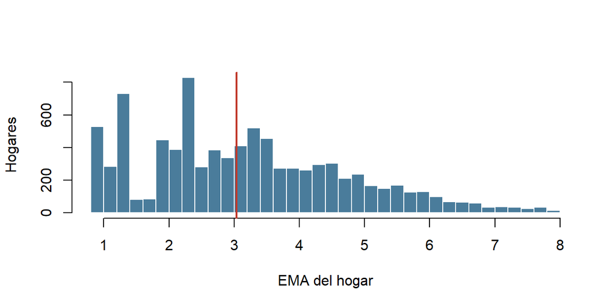

Figura 1: Distribución del EMA por hogar

**Cobertura del cálculo: 8,892 de 8,892 hogares (100%) tienen EMA calculado para todos sus miembros.**

### 4.1 Relación entre tamaño del hogar y EMA

Tabla 4: EMA mediano según número de miembros del hogar

| Miembros | Hogares | EMA mediano | EMA por miembro |
| --- | --- | --- | --- |
| 1 | 1,519 | 1.04 | 1.04 |
| 2 | 1,882 | 2.17 | 1.09 |
| 3 | 1,951 | 3.03 | 1.01 |
| 4 | 1,703 | 3.98 | 1.00 |
| 5 | 1,063 | 5.01 | 1.00 |
| 6 | 481 | 5.95 | 0.99 |
| 7 | 170 | 7.02 | 1.00 |
| 8 | 84 | 7.95 | 0.99 |

## 5 Las dos secciones del cuestionario

La ENGIH releva el consumo por dos vías: la **Sección 2** registra las existencias del hogar y la **Sección 3A** las adquisiciones diarias. Miden cosas distintas, y la elección entre ellas tiene consecuencias directas sobre el resultado.

Tabla 5: Ingesta energética según qué secciones se incluyen

| Variante | Hogares | Energía mediana | Energía media | Hierro (mg) | Folato (µg DFE) | Vit. A (µg RAE) |
| --- | --- | --- | --- | --- | --- | --- |
| Sec 2 | 6,216 | 1,173 | 1,466 | 7.8 | 559 | 31 |
| Sec 2 + Sec 3A | 8,774 | 2,153 | 2,755 | 14.2 | 811 | 173 |
| Sec 3A | 8,653 | 1,200 | 1,741 | 7.3 | 248 | 136 |

**Ninguna sección por separado produce un resultado fisiológicamente plausible.** Ambas arrojan alrededor de 1.200 kcal por EMA y día, aproximadamente la mitad del requerimiento de referencia. Solo la suma alcanza un valor compatible con el consumo real.

La explicación es que las secciones son **mayormente complementarias, no redundantes**: capturan alimentos distintos. Se aprecia en el perfil de nutrientes, donde el folato es sustancialmente mayor en la Sección 2 y la vitamina A en la Sección 3A, porque cada instrumento recoge grupos de alimentos diferentes.

Tabla 6: Aporte de cada sección al consumo total

| Seccion | Filas | Hogares | Gramos por EMA/día (mediana) |
| --- | --- | --- | --- |
| Sec 2 | 43,393 | 6,216 | 25.3 |
| Sec 3A | 260,014 | 8,653 | 11.6 |

**ImportanteSolapamiento en alimentos almacenables**

Un mismo hogar puede aparecer en ambas secciones para el mismo alimento: tenía arroz almacenado **y** compró arroz durante el período. El análisis de los hogares con ingesta energética implausiblemente alta confirma este mecanismo: arroz, aceite, azúcar y leche —todos almacenables— encabezan el listado y aparecen en ambas secciones.

**Esto sobrestima el consumo de los alimentos almacenables**, entre ellos tres de los cuatro vehículos de fortificación.

El refinamiento metodológico apropiado es la **disponibilidad neta** (existencias iniciales + adquisiciones − existencias finales). Los datos necesarios están disponibles en la Sección 2 y su implementación queda identificada como línea de trabajo prioritaria.

**La decisión sobre qué variante adoptar corresponde al equipo técnico**, no se resuelve en este reporte. Las tres se presentan con sus consecuencias para que la decisión se tome con evidencia.

## 6 Supuestos del cálculo del EMA

Documentados de forma explícita, según requiere el numeral 6 de las Notas Metodológicas de los Términos de Referencia.

| Supuesto | Tratamiento | Estado |
| --- | --- | --- |
| Requerimiento energético por edad y sexo | Tabla de referencia de la metodología proporcionada | Aplicado |
| Menores de 1 año | Valor provisional de 600 kcal/día | **Pendiente de contrastar con FAO/WHO/UNU 2004** |
| Nivel de actividad física | Se asume moderado para toda la población adulta | Limitación declarada |
| Embarazo y lactancia | Sin ajuste | La variable no se incorporó en esta etapa |
| Peso corporal | Fijo por sexo, sin variación individual | Limitación declarada |

La ausencia de ajuste por embarazo y lactancia merece precisión: el marco analítico de referencia contempla desagregar por mujeres en edad fértil, embarazadas y lactantes, lo que requiere el módulo demográfico completo de la encuesta. **Queda identificado como verificación pendiente**, no como una limitación insalvable de la fuente.

## 7 Limitaciones

- **Cobertura del cálculo.** Las cifras se construyen sobre las observaciones que completan los tres componentes de la fórmula. El detalle por sección y los motivos de exclusión se documentan en el reporte R1.
- **Sin intervalos de confianza.** La ENGIH tiene diseño muestral complejo (8 estratos, 933 unidades primarias, factor de expansión). Las variables están disponibles; hasta incorporarlas mediante `srvyr` **no se reportan intervalos**, en lugar de reportarlos incorrectamente estrechos.
- **Consumo aparente, no ingesta individual.** Estos datos miden lo que el hogar adquiere o tiene disponible, no lo que cada persona ingiere. No se captura la distribución intrafamiliar, el desperdicio ni el consumo fuera del hogar.
- **La Sección 3B (alimentos consumidos fuera del hogar) está excluida**, ya que requiere factores de receta y rendimiento no disponibles en esta fuente.
- **El consumo de alimentos almacenables está sobrestimado** por el solapamiento entre secciones descrito arriba.

## 8 Conclusión

El modelo de base es implementable sobre la ENGIH 2018. La cadena completa —estandarización de unidades, factores de conversión, porción comestible, período de medición y normalización por EMA— produce resultados en rangos fisiológicamente plausibles, y cada eslabón está documentado y es reproducible.

Las limitaciones identificadas no impiden el análisis: acotan su interpretación, y cada una tiene una vía de resolución especificada.

*Generado desde el pipeline reproducible del proyecto: `scripts/01_import.R` → `scripts/05_ingesta_micronutrientes.R`.*